# CubOps: Manual de Usuario

Julio Sergio Santana

19 de enero de 2018

# 1 Introducción

**CubOps** es una aplicación Web que le permitirá operar sobre un conjunto de puntos, típicamente estaciones meteorológicas, cada uno de los cuales contiene información temporal de un número finito de variables, como pueden ser, precipitación, temperaturas mínimas y máximas.

En general, el sistema trabaja con puntos a los que se le ha asociado un número de variables cualquiera, que dependen de una fecha secuencial en días.

Para el análisis y la aplicación de operaciones o producción de algunos gráficos, el sistema permite generar una tabla completa para una variable seleccionada, cada una de cuyas columnas corresponde a cada uno de los puntos o estaciones de la base de datos. Posteriormente, se pueden aplicar operaciones estadísticas (media, rango, mediana, *quantile*, etc.), a los datos de la columna, o a una selección de esta de acuerdo con las fechas establecidas. El sistema también permite la producción de varios tipos de gráficos simples para las columnas de las tablas resultantes, a saber: histogramas, *boxplots*, o series de tiempo.

En cualquier momento, el usuario puede descargar las tablas resultantes de sus operaciones en un formato estándar (csv), que podrá ser leído fácilmente por hojas de cálculo, tales como *LibreOffice Calc*, o *Excel*, o por otros sistemas o programas para desarrollar procesos adicionales con la información.

## 1.1 Bases de datos de ejemplo

Para que el usuario pueda experimentar con el sistema se proveen las siguientes bases de datos para descargase en un equipo local:

1. Datos de más de 60 estaciones en la cuenca del río Usumacinta: http://gradiente.imta.mx/content/databases/UsumacintaDatos.zip
2. Datos de 14 estaciones en la cuenca del río Conchos: http://gradiente.imta.mx/content/databases/ConchosDatos.zip
3. Información geográfica de ubicación las estaciones registradas en CLICOM: http://gradiente.imta.mx/content/databases/Estaciones.csv

Estos datos pueden utilizarse a partir de las acciones que se describen a partir de la sección 3.5 (CubOps: colección de los datos).

# 2 Aspecto general de CubOps

Para ejecutar el sistema basta con introducir la siguiente URL en alguno de los *browsers* comunes de la Web, tales como Chrome o Firefox:

http://gradiente.imta.mx:3838/CubOps

El sistema desplegará una interfaz al usuario, en la cual podrá introducir sus peticiones y recibir sus respuestas. La Fig. 1 Muestra la apariencia general del sistema una vez que se han desarrollado varias operaciones. Al inicio de la sesión, sólo se muestra el menú etiquetado como **Acción**, en el área **A** de la Fig. 1, y las áreas **B** y **C** se muestran vacías, aunque, al pulsar en la pestaña etiquetada como **Manual**, en el área **B**, se desplegará el presente documento.

**Figura 1.** Apariencia general de CubOps

[figure not shown]

Apariencia CubOps

En esa figura se destacan la tres áreas principales del sistema, a saber:

1. **A**. **Panel de acciones**. Aquí el usuario define diversas acciones que van desde la captura de sus datos, hasta la operación sobre algún subconjunto de ellos para definir alguna estadística.
2. **B**. **Panel de resultados tabulares**. Los resultados tabulares de las operaciones se muestran en este espacio.
3. **C**. **Panel de operaciones y resultados gráficos**. Aquí el usuario puede definir diversos tipos de gráfico para alguna de las columnas del resultado tabular.

# 3 Los datos y su recolección

Generalmente, los datos de cada estación estarán dados como una tabla en la que se proporciona una fecha en cada renglón y con una columna para cada una de las variables que se han registrado para la estación a lo largo del tiempo. En seguida se muestran los diez primeros renglones de una estación con tres variables: Prec (precipitación), Tmax (temperatura máxima) y Tmin (temperatura mínima).

```
##    Year Month Day Prec Tmax Tmin
## 1  1951     1   1  0.0 31.3 17.6
## 2  1951     1   2  0.0 32.1 18.7
## 3  1951     1   3  0.0 32.1 18.3
## 4  1951     1   4  3.5 30.7 20.3
## 5  1951     1   5  0.0 30.7 19.7
## 6  1951     1   6  0.0 30.9 18.4
## 7  1951     1   7  0.0 30.8 17.9
## 8  1951     1   8  0.0 21.8 18.3
## 9  1951     1   9 20.0 23.6 14.3
## 10 1951     1  10  0.0 27.6 14.4
```

De esta forma los datos de cada estación se pueden mantener en un archivo de hoja de cálculo, como LibreOffice Calc o Excel. Para su manejo en el presente sistema, dichos archivos deberán exportarse al formato estándar CSV ( *comma separated value* ), aunque ellos podrán estar dispersos en una estructura de directorios o carpetas.

Los archivos CSV pudieran no traer el encabezado que identifica a cada una de las columnas, pero en ese caso el sistema entenderá que, aparte de la fecha que se debe dar en las primeras tres columnas, las columnas restantes serán sólo tres que corresponderán a las variables pp (precipitación), tmax (temperatura máxima) y tmin (temperatura mínima), en ese orden.

## 3.1 Los archivos y sus nombres

Para poder manejar dentro del sistema un conjunto de archivos de tablas como las descritas en la sección 3, éstas se pueden encontrar dispersas dentro de una estructura de directorios/subdirectorios (carpetas), del sistema operativo, tal como se muestra en la Fig. 2. Sin embargo, para que el sistema pueda reconocer los archivos en cuestión, ellos deben ser nombrados de acuerdo con una estructura sintáctica particular que se describe a continuación:

1. El primer caracter del nombre debe ser una letra “s”, minúscula.
2. En seguida, una secuencia de caracteres alfanuméricos que representan el *identificador* de la estación correspondiente al archivo.
3. Después una letra “H”, mayúscula y la secuencia de caracteres “.csv”, que identifican el tipo de archivo.

Por ejemplo, el archivo de nombre “s3394H.csv” contendría la tabla de información de la estación 3394 en formato CSV. A estos archivos se les denominará *archivos de estaciones*.

## 3.2 Los archivos y su estructura

Externamente, como se mustra en la Fig. 2, los archivos de estaciones podrán estar dispersos en una estructura de directorios. Internamente, la condición es que la estructura de las tablas sea la misma para todos los archivos, esto es, todos deben tener el mismo número de columnas, con las tres primeras para la fecha en orden: año, mes y día, y las restantes para las variables que se registren en las estaciones, en el mismo orden para todas las tablas. Si las tablas llevan o no encabezado, esto debe ser igual para todas ellas.

**Figura 2.** Ejemplo de estructura de directorios con archivos CSV

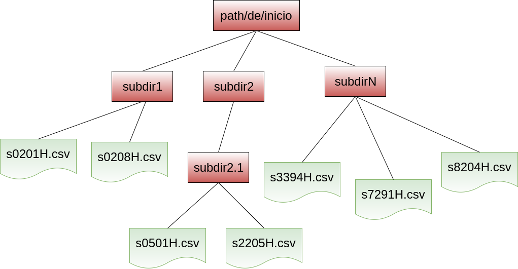

Estruct Dir

## 3.3 Empaquetado de los archivos

Para que el sistema pueda digerir la información correspondiente a un conjunto de estaciones como la que se ha ilustrado en las secciones anteriores y que se muestra gráficamente en la Fig. 2, es necesario empaquetarlo en un solo archivo de tipo ZIP.

En un sistema operativo Linux o Unix, el comando para efectuar esa operación es:

```bash
zip -r arch.zip path/de/inicio
```

Al final de la operación toda la estructura de archivos se tendría en el paquete de nombre “arch.zip”, en el caso del ejemplo.

## 3.4 Información geográfica de estaciones

Aparte de la información de diversas variables de las estaciones, que se empaca en un archivo de tipo ZIP, como se ha mostrado en las secciones anteriores, es necesario proveer también de una tabla que registre las coordenadas geográficas en formato CSV. Un ejemplo de la estructura de esta tabla se muestra a continuación:

```
##    Clave                  Nombre  Latitud  Longitud
## 1   1003          CALVILLO (SMN) 21.88333 -102.7189
## 2   1004            CA?ADA HONDA 22.00778 -102.1981
## 3   1005        PRESA EL NIAGARA 21.77889 -102.4414
## 4   1006           EL TULE (SMN) 22.08167 -102.0914
## 5   1007       JESUS MARIA (SMN) 21.96222 -102.3447
## 6   1008 PUERTO DE LA CONCEPCION 22.20250 -102.1344
## 7   1009          LA LABOR (SMN) 21.96222 -102.6947
## 8   1010               LA TINAJA 22.16528 -102.5558
## 9   1011                 MALPASO 21.85833 -102.6628
## 10  1012        PRESA MEDIA LUNA 21.79250 -102.8017
```

La tabla debe contener por lo menos tres columnas, la correspondiente a la “Clave” de la estación, y las correspondientes a la “Longitud” y “Latitud” de la estación, con esos nombres de columna. Además, la tabla debe contener *al menos* la información de las estaciones que se consignan en el empaquetamiento de la sección 3.3.

## 3.5 CubOps: colección de los datos

Para que el sistema colecte toda la información de las estaciones se debe seleccionar, en el menú de Acciones, la entrada “**Colecta Datos**”, como se muestra en la Fig. 3.

**Figura 3.** Colección de datos

[figure not shown]

Una vez seleccionada esta acción el sistema provee sendos botones para la *subida* de los dos archivos de interés, descritos en las secciones 3.3 y 3.4; esto es, el paquete de archivos ZIP con la información de las variables en las estaciones y el archivo CSV con la información geográfica de las estaciones. El despliegue de estos botones se muestra en la Fig. 4, a continuación.

**Figura 4.** Botones para la *subida* de archivos de datos

[figure not shown]

Sube datos

Ya que se han subido o cargado estos datos, lo cual se muestra en las barras de progreso de la carga en la Fig. 5, se debe oprimir el botón “**Ejecuta**”, en la parte inferior del panel de Acciones, para proceder al armado completo de la estructura de información que utiliza internamente el sistema. En la Fig. 5, se muestra el resultado, donde, en el panel de resultados tabulares, se muestra un texto que da alguna pista del armado de dicha estructura.

**Figura 5.** Armado de la estructura de información

[figure not shown]

ArmEstruct info

## 3.6 Descarga y recarga de la estructura de información

Una vez construída la estructura de información, como se ha mostrado en las secciones anteriores, ésta se puede descargar de manera local para reutilizarse posteriormente por el sistema, sin necesidad de reconstruírla a partir de un archivo de tipo ZIP. La descarga se hace seleccionando la entrada “**Guardar Archivo Datos**”, en el menú de acciones (ver Fig. 3). La estructura de información queda guardada en un archivo de tipo RDS, que es un archivo binario del lenguaje de programación R.

La recarga de la estructura de información, se hace seleccionando la entrada “**Lee Archivo**”, en el menú de Acciones (ver Fig. 3). Una vez leído algun archivo de este tipo (RDS), el resultado sería semejante al de la construcción de la estructura que se muestra en la Fig. 5.

# 4 Selección de variables

El sistema maneja una estructura de información que se ha construído como se ha señalado en las secciones anteriores. La Fig. 6 muestra de manera gráfica la apariencia de dicha estructura.

**Figura 6.** La estructura de la información

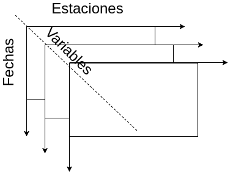

Estruct Info

La estructura puede ser concebida como *un número determinado de tablas*, tantas como variables haya registradas, cuyos renglones serían las fechas y cuyas columnas corresponderían con cada una de las estaciones (ver Fig. 6). El presente sistema permite operar sobre cada una de las tablas de la estructura; esto es, con cada una de las variables registradas. De modo que el primer paso, antes de cualquier operación, es la selección de una tabla o variable para trabajar con ella.

Para proceder a la selección de la variable, se debe entrar al menú de Acciones y seleccionar de ahí la entrada “**Elige Variable**” (ver Fig. 3). Esta acción abre un menú, “**Variable a revisar**”, con el conjunto de variables que se pueden revisar, como se muestra en la Fig. 7.

**Figura 7.** Conjunto de variables que pueden ser revisadas

[figure not shown]

Conj vars

Una vez que se elige la variable deseada, y luego de que se oprime el botón “**Ejecuta**”, en el panel de resultados tabulares, aparece la tabla correspondiente a la variable, con los dos primeros renglones mostrando las coordenadas geográficas de las estaciones. La tabla se puede navegar por páginas. Este resultado se muestra abajo en la Fig. 8.

**Figura 8.** Tabla correspondiente a una variable

[figure not shown]

Tab Var

La tabla resultante, se puede descargar a su equipo local, en el formato estándar CSV, oprimiendo el botón “**Descarga Resultado**”, que aparece en la parte inferior del panel de resultados tabulares (Ver Fig. 8).

## 4.1 Selección de variables y operaciones

En la sección siguiente se empieza a tratar el asunto de la aplicación de operaciones sobre los datos contenidos en la tabla o variable seleccionada. Dado que **las operaciones se aplican sobre la tabla visible**, cada vez que se quiera aplicar una nueva operación sobre los mismos datos, será necesario *regresar* y elegir nuevamente la misma variable para restablecer la tabla de origen. Esto, como se verá más adelante en la sección 6.3, es porque hay resultados que se obienenen de aplicar consecutivamente varias operaciones sobre las tablas consecutivas resultantes, por ejemplo, en el caso de los promedios de sumas acumulativas de precipitación.

# 5 Operaciones estadísticas sobre columnas completas

El sistema permite ejecutar alguna de las operaciones estadísticas disponibles, sobre la series completas de datos de todas las columnas exhibidas, que corresponden a las estaciones registradas. Como se verá más adelante, algunas operaciones, como la media, la varianza, o la mediana, reportarán un sólo resultado numérico para cada serie de datos, mientras que otras, como el rango o los cuantiles, reportarán dos o más resultados.

Para seleccionar una operación cualquiera, primeramente se toma del menú de Acciones, la entrada “**Operación**”, lo que abre un menú de “**Operación**” con todas las operaciones estadísticas disponibles, tal como se muestra en la Fig. 9. Al momento, las operaciones disponibles son: la media (mean), la mediana (**median**), la varianza (**var**), la desviación estándar (**sd**), la sumatoria (**sum**), el valor mínimo (**min**), el valor máximo (**max**), el rango (**range**), compuesto por los valores mínimo y máximo, y los cuantiles (**quantile**).

**Figura 9.** Menú de operaciones

[figure not shown]

Menu Op

Nótese, en la Fig. 9, que en la tabla sobre la cuál se va a operar, hay columnas sin datos, tales como las etiquetadas “s27006” y “s27021”.

Ya que se ha elegido la operación, por ejemplo *la mediana*, y se le ha dado un nombre, en el campo textual provisto para ello, por ejemplo “mm”, se procede a ejecutar dicha operación, para todas las columnas con datos al oprimir el botón “**Ejecuta**” que aparece en la parte inferior del panel de acciones. Los resultados de la operación se muestran en una tabla como la que se muestra en la Fig. 10, donde la operación en cuestión arroja un único resultado para cada serie de datos (columna).

**Figura 10.** Operación de *un solo resultado* (mediana)

[figure not shown]

Nuevamente, la tabla resultante puede ser descargada en un equipo local, en el formato estándar CSV, al oprimir el botón “**Descarga Resultado**”.

## 5.1 Operaciones con más de un resultado: cuantiles

Como se mencionó antes, hay operaciones estadísticas que arrojarán más de un dato a la salida. Tal es el caso de los cuantiles. Si se elige esta operación en el menú de “**Operación**”, la interfaz del sistema despliega un campo de texto etiquetado como “**Probabilidades separadas por’,’**”, en el que se pueden especificar las probabilidades de *ruptura*, separadas por comas, de los cuantiles para el cálculo. Por omisión, estas probabilidades son: 0, 0.25, 0.50, 0.75 y 1.0, lo que corresponde a los así denominados *cuartiles* de cada serie. El resultado, que se muestra en la Fig. 11, estaría dado, en ese caso, por 5 renglones, nombrados como: qq.0%, qq.25%, qq.50%, qq.75% y qq.100%. El prefijo “qq” en todos los nombres de los renglones de la tabla, se ha tomado del campo de texto “**Nombre de su operación**”, que es un nombre arbitrario que provee el usuario del sistema.

**Figura 11.** Cuartiles para cada una de las columnas

[figure not shown]

Cuarts

La interpretación de la información en esa tabla es más o menos sencilla. Por ejmplo, para la primera columna, etiquetada como “s27001”, la serie de datos de temperatura mínima, que fue la variable elegida, tienen un valor mínimo y máximo de 10° y 34°, que en la columna se muestran como los renglones qq.0% y qq.100%, respectivamente, lo que se interpreta como 0% de los datos están tienen un valor menor que 10° y 100% de los datos, esto es, todos, tienen un valor menor o igual que 34°. En este caso, la mediana de los datos es 23.1°, lo que significa que el 50% de los datos es menor o igual a este valor (qq.50%).

Cambiar las probabilidades en el campo de texto, permite desarrollar el calculo de otro tipo de cuantiles. Por ejemplo, si se quisieran calcular los terciles, se podría establecer la siguiente serie de probabilidades: 0, 0.3333, 0.6667, y 1.0. El resultado de esta operación se muestra en la Fig. 12.

**Figura 12.** Terciles para cada una de las columnas

[figure not shown]

Tercs

Nuevamente, en cualquiera de estos casos, la tabla resultante, por ejemplo, con cuartiles o terciles, puede ser descargada en un equipo local, en el formato estándar CSV, al oprimir el botón “**Descarga Resultado**”.

Nótese además, que las columnas que no tenían información originalmente, tampoco reportan resultados en ninguno de los dos casos ejemplificados.

# 6 Estratificaciones de datos y operaciones sobre ellas

Al aplicar las distintas operaciones estadísticas, las fechas, que obran como nombre de los renglones de la tabla, se pueden usar para ejecutar distintas *estratificaciones* de los datos. Se puede definir como un **estrato** de una *estratificación*, al conjunto de renglones que comparten alguna porción de la fecha, por ejemplo, el año y el mes; esto es, por ejemplo, los 31 renglones del mes de marzo de 1961, constituirían un estrato para ese caso. La **estratificación** sería entonces el conjunto de todos los estratos que la componen.

## 6.1 Definición de una estratificación en CubOps

Después de haber seleccionado alguna variable, y al momento de elegir alguna operación, se puede definir también alguna estratificación a partir de las fechas. Esto se hace, mediante el agrupamiento en los campos de fecha, como se muestra en la Fig. 13.

**Figura 13.** Agrupamientos

[figure not shown]

Agrupa

En el caso de la Fig. 13, se ha elegido el año y el mes, mientras que el día se ha descartado. Esto significa que los estratos se definirán a partir del año y el mes solamente. Esto es, la operación que se elija, la media en este caso, se ejecutará para los conjuntos de renglones que tengan el mismo año y mes, o sea, se estarán obteniendo los promedios mensuales de temperatura mínima a lo largo de todos los años en el registro. Así, la Fig. 14, muestra el resultado de esta operación. Nótese que en las fechas, el campo correspondiente al día se ha reemplazado por un asterisco “*”. Entonces, por ejemplo, el primer dato de la columna etiquetada como “s27001”, se encuentra en el renglón “1951-01-*”; ello indica que la media de temperaturas mínimas durante el primer mes de año 1951 es de 16.887°, y así son también todas las interpretaciones de todas las columnas y renglones de la tabla resultante.

**Figura 14.** Resultados de una operación estratificada

[figure not shown]

Res Estratif

Nuevamente, esta tabla resultante, puede ser descargada en un equipo local, en el formato estándar CSV, al oprimir el botón “**Descarga Resultado**”.

## 6.2 Estratificaciones y operaciones con resultados múltiples

Cuando se ejecutan operaciones combinadas con estratificaciones de la tabla, se puede ver en la Fig. 14, que la tabla resultante arroja un renglón para cada estrato de los datos originales. Esto no representa ningún problema si la operación arroja un único resultado, como es el caso de la media, la mediana, o la desviación estándar, por ejemplo. En este punto surge la pregunta: ¿cómo maneja CubOps el caso de operaciones que arrojan más de un resultado?, ya que por cada estrato y estación se tendrían resultados múltiples. La respuesta es que el sistema **expande la columna correspondiente a una estación, a tantas columnas como resultados arroje la operación en cuestión**. La Fig. 15 muestra, como ejemplo, el caso de la producción de *terciles*, por medio de la operación “**quantile**”, para una tabla original de temperaturas mínimas. Es de notarse aquí que los nombres de las columnas están formados por el nombre de la estación original, seguido del caracter “:”, y luego un conjunto de caracteres que permitirán identificar cada caso, que para el ejemplo de los terciles son los porcentajes de probabilidad elegidos.

**Figura 15.** Terciles para datos estratificados

[figure not shown]

Terc estrat

## 6.3 Aplicación recurrente de operaciones

Hay ocasiones en que es necesario aplicar una nueva operación al resultado de otra operación. Tal es el caso de los **promedios mensuales de precipitaciones acumuladas durante el mes**. Con este propósito, CubOps ha sido diseñado para aplicar cualquiera de las operaciones disponibles sobre la tabla actualmente visible en el panel de resultados tabulares.

Por ejemplo, para producir justamente los **promedios mensuales de precipitaciones acumuladas durante el mes**, primeramente se selecciona la variable precipitación de la estructura de información vigente, como se muestra en la Fig. 16.

**Figura 16.** Selección de la variable precipitación

[figure not shown]

Recurr Prec

Ahora se procede a acumular las precipitaciones que ocurrieron cada mes, para ello se selecciona la operación **sum** (sumatoria), y en el **Agrupamiento** se elimina el campo correspondiente al día, con el fin de producir estratos mensuales para todos los años, tal como se muestra en la Fig. 17. Ahí, por ejemplo, en el renglón “1951-03-*” y la columna “s27004”, se encuntra el valor 133.6, lo que significa que durante el mes de marzo del año 1951, se observó una precipitación acumulada durante todo el mes de 133.6 mm en la estación 27004.

**Figura 17.** Acumulación de precipitaciones por mes

[figure not shown]

Recurr Prec1

Finalmente, para producir los promedios mensuales de esos resultados para toda la serie, se procede a elegir la operación **mean** y se elimina ahora el campo correspondiente al año en el **Agrupamiento**. Después de oprimir el botón **Ejecuta**, se obtiene el resultado que se muestra en la Fig. 18. En el renglón “*-09-*” y columna “s27021”, se observa un valor de 322.705, lo que significa que el promedio de precipitaciones acumuladas mensuales en el mes de septiembre, para la estación 27021, es de 322.705 mm.

**Figura 18.** Promedios de precipitaciones acumuladas mensuales

[figure not shown]

Recurr Prec2

# 7 Gráficas sencillas con CubOps

Como una cualidad adicional, **CubOps** permite generar algunos tipos de gráficas sencillas, a saber: series, histogramas y *boxplots* (diagramas de cajas). Estas gráficas permiten tener una mayor visión general de los resultados que se presentan en las tablas del panel de resultados tabulares. A continuación se indica cómo explotar esta característica del sistema.

## 7.1 Gráficos de información completa de estaciones (columnas)

Después de elegir alguna de las variables disponibles, como es el caso que se ha presentado en la Fig. 8, se puede proceder a producir alguna de las gráficas disponibles. Para ello es necesario primeramente, seleccionar alguna de las columnas en la tabla y luego el tipo de gráfico deseado. Por ejemplo, en la Fig. 19 se ha seleccionado la columna “s27040” y se ha elegido la producción de un gráfico de tipo “hist” (histograma); después de esa selección el gráfico correspondiente se muestra en la parte inferior, conocida como *panel de resultados gráficos*. El gráfico producido se puede salvar en un archivo gráfico, si se oprime el botón etiquetado como **Descarga Gráfico**.

**Figura 19.** Producción de gráficos con **CubOps**

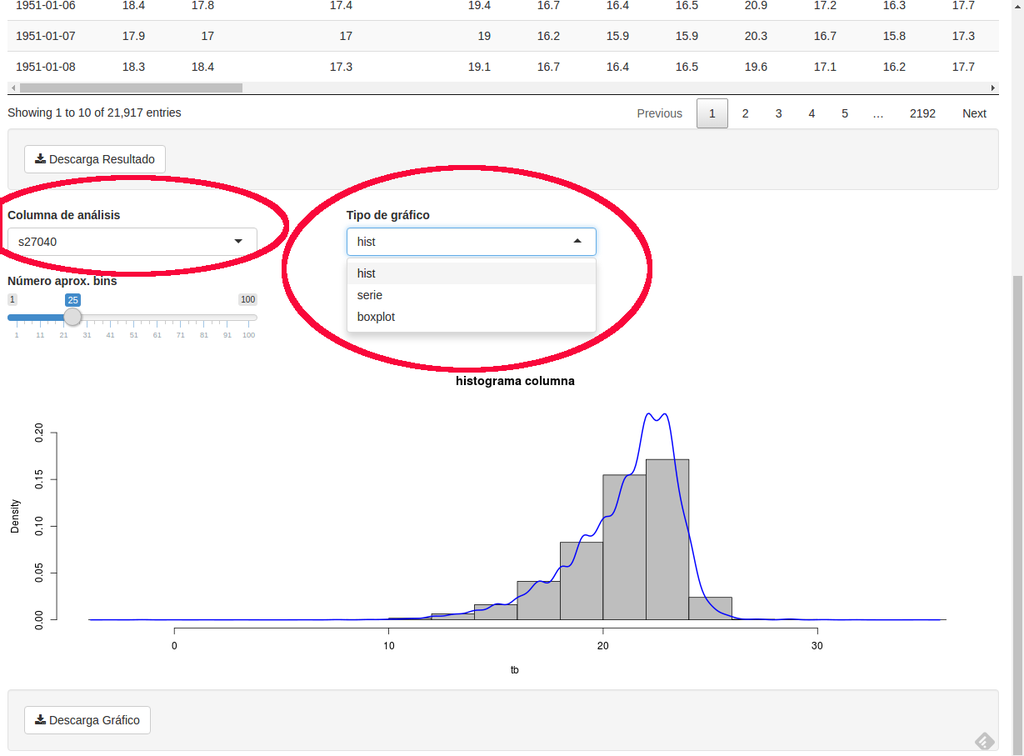

Para el caso particular de los histogramas, aparece además un control, conocido como *slider*, que permite incrementar o disminuir el número de barras que se presentan en el histograma. Al desplazar de botoncito, dinámicamente se incrementan o decrementan las barras que aparecen, como se puede apreciar el la Fig. 20.

**Figura 20.** Otros controles en las gráficas

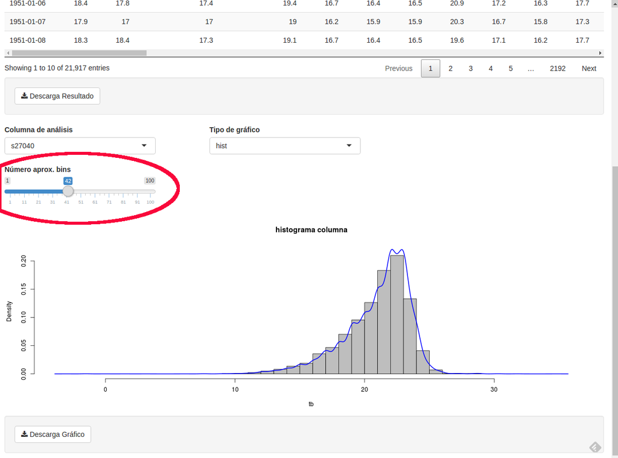

Grafico 2

## 7.2 Algunos usos de los gráficos

Cuando ya se ejecutan operaciones en las estaciones o columnas, los gráficos producidos pueden ser más interesantes. Por ejemplo, en la Fig. 21, se observa un gráfico de tipo “serie”, que se ha producido después de haber ejecutado la operación “quantil” sobre todos los datos de temperatura mínima de la columna “s27040”. Aquí, en el eje de las abscisas se tienen los rangos de cuantil, y en las ordenadas, los valores de las temperaturas.

**Figura 21.** Gráfica de los cuantiles

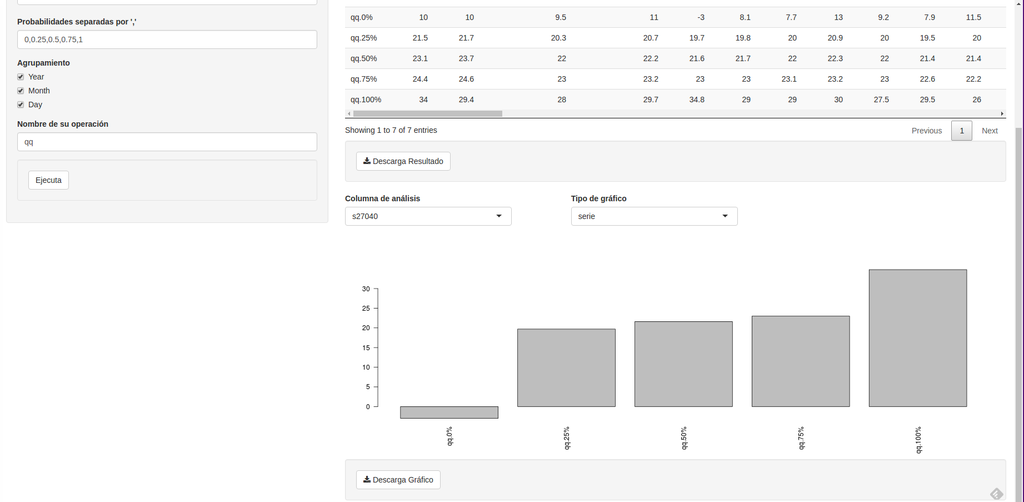

Grafico 3

Otro interesante gráfico a considerar son los *boxplots*, que dan también una idea de la distribución de la información. La Fig. 22 muestra un gráfico de este tipo para las temperaturas mínimas de la estación “s27004”.

**Figura 22.** Gráfica tipo *boxplot*

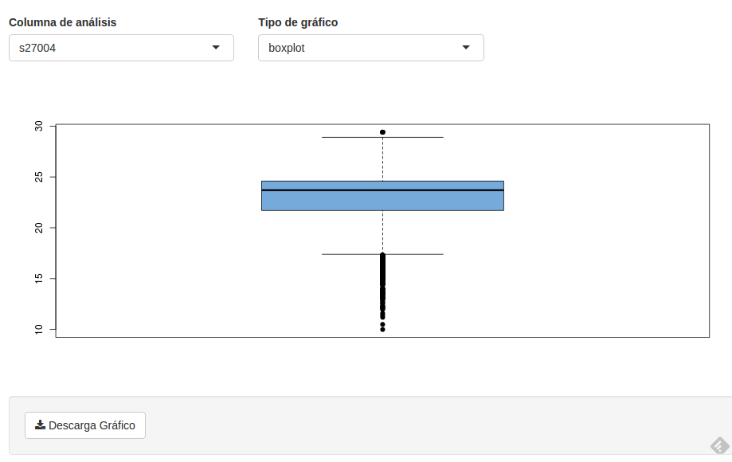

Grafico 4

Un caso interesante es la graficación de la climatología de las precipitaciónes acumuladas mensuales, cuyo cálculo se ha presentado en forma tabular en la Fig. 18. Para graficar esto, basta con seleccionar alguna estación y el tipo de gráfico “serie”; la gráfica resultante se muestra en la Fig. 23.

**Figura 23.** Climatología de precipitaciones acumuladas mensuales

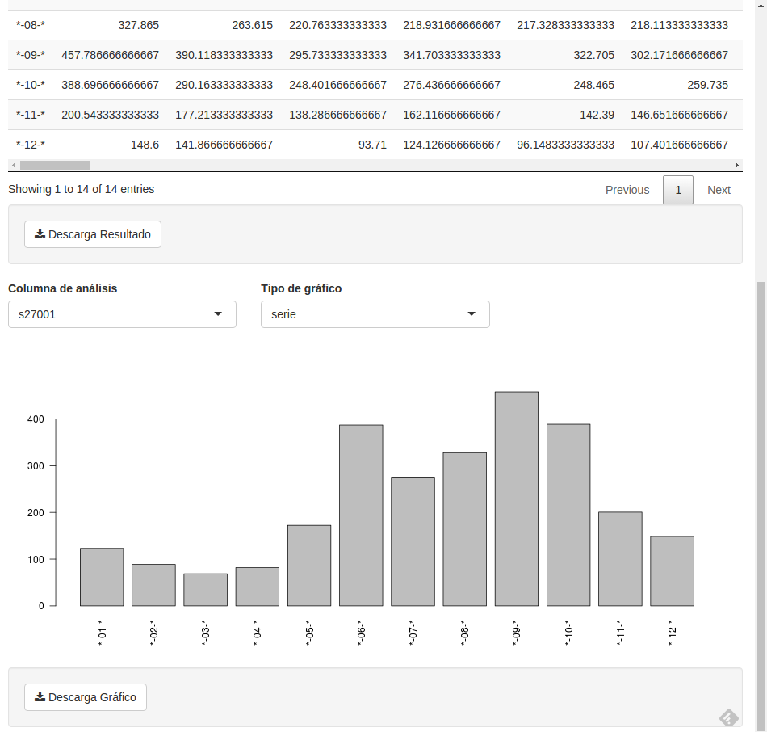

Grafico 5